# Лабораторная работа №5

Анализ файловой системы Linux.Команды для работы с файлами и каталогами

Салькова К. М.

Российский университет дружбы народов, Москва, Россия

# Информация

## Докладчик

- Салькова Кристина Михайловна
- студентка НБИбд-04-22
- Российский университет дружбы народов

# Вводная часть

## Вводная часть

В данной лабораторной работе мы рассмотрим: - Команды для работы с файлами и каталогами - Копирование файлов и каталогов - Перемещение и переименование файлов и каталогов - Права доступа - Изменение прав доступа - Анализ файловой системы

## Объект и предмет исследования

- Команда touch - Команда fsck - Команда mkfs - Команда kill
- Команда mount - Команда cat - Команда less - Команда ls
- Команда chmod - Команда rm - Команда cp - Команда mv

# Цель работы

## Цель работы

Целью лабораторной работы является ознакомление с файловой системой Linux, её структурой, именами и содержанием каталогов. Приобретение практических навыков по применению команд для работы с файлами и каталогами, по управлению процессами (и работами), по проверке исполь- зования диска и обслуживанию файловой системы.

# Выполнение лабораторной работы

# Первый этап

## 1

Выполняем все примеры, приведённые в первой части описания лабораторной работы.

## 1

# Второй этап

## 2

2.1. Скопируем файл /usr/include/sys/io.h в домашний каталог и назовите его equipment. 2.2. В домашнем каталоге создадим директорию ~/ski.plases. 2.3. Переместите файл equipment в каталог ~/ski.plases. 2.4. Переименуйте файл ~/ski.plases/equipment в ~/ski.plases/equiplist.

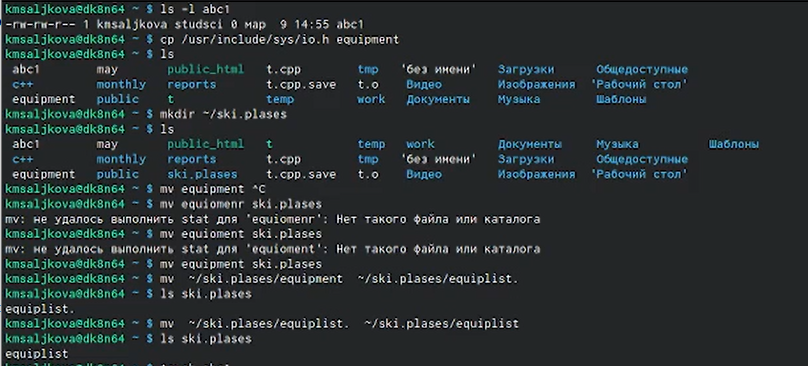

выполнение команд

## 2

2.5. Создадим в домашнем каталоге файл abc1 и скопируйте его в каталог ~/ski.plases, назовите его equiplist2. 2.6. Создадим каталог с именем equipment в каталоге ~/ski.plases. 2.7. Переместим файлы ~/ski.plases/equiplist и equiplist2 в каталог ~/ski.plases/equipment. 2.8. Создадим и переместим каталог ~/newdir в каталог ~/ski.plases и назовем его plans.

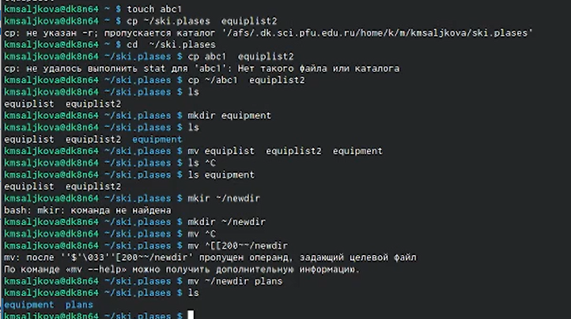

выполнение команд

# Третий этап

## 3

Определим опции команды chmod, необходимые для того, чтобы присвоить перечис- ленным ниже файлам выделенные права доступа, считая, что в начале таких прав нет

## 3.1

drwxr–r– … australia

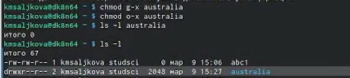

результат

## 3.2

drwx–x–x … play

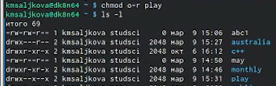

результат

## 3.3

-r-xr–r– … my_os

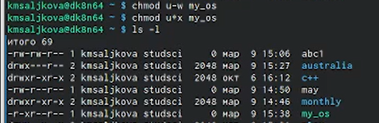

результат

## 3.4

-rw-rw-r– … feathers

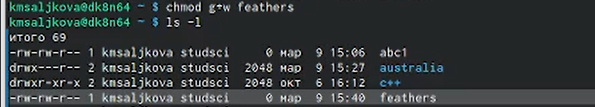

результат

# Четвёртый этап

## 4

4.1. Просмотриь содержимое файла /etc/password. (такой файл отсутствует) 4.2. Скопируйте файл ~/feathers в файл ~/file.old.ls 4.3. Переместите файл ~/file.old в каталог ~/play. 4.4. Скопируйте каталог ~/play в каталог ~/fun. 4.5. Переместите каталог ~/fun в каталог ~/play и назовите его games.

## 4

4.6. Лишим владельца файла ~/feathers права на чтение. 4.7. Что произойдёт, если вы попытаетесь просмотреть файл ~/feathers командой cat? 4.8. Что произойдёт, если вы попытаетесь скопировать файл ~/feathers?

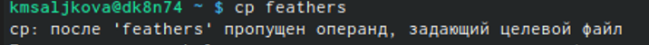

выполнение команд

## 4

4.9. Дайте владельцу файла ~/feathers право на чтение.

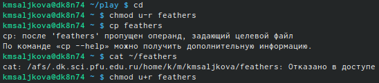

выполнение команд

## 4

4.10. Лишим владельца каталога ~/play права на выполнение. 4.11. Перейдем в каталог ~/play. Что произошло? ничего не произошло(

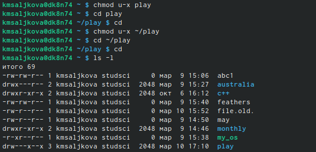

выполнение команд

## 4

4.12. Дайте владельцу каталога ~/play право на выполнение.

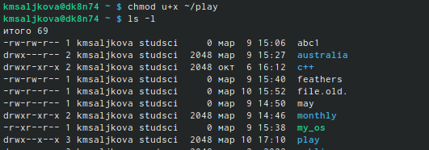

выполнение команды

# Пятый этап

## 5

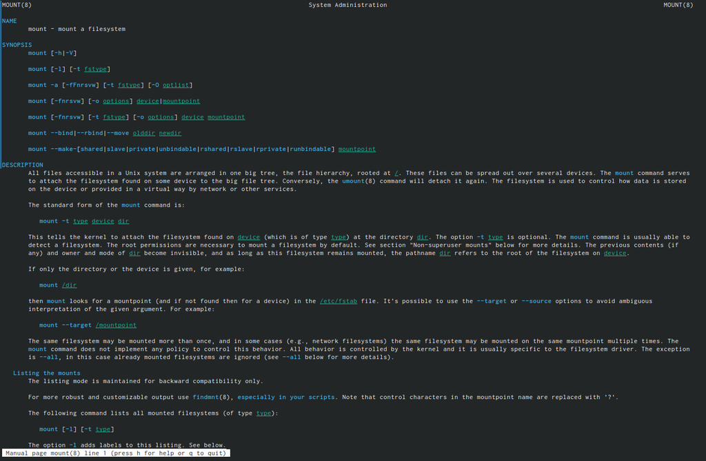

man mount

## 5

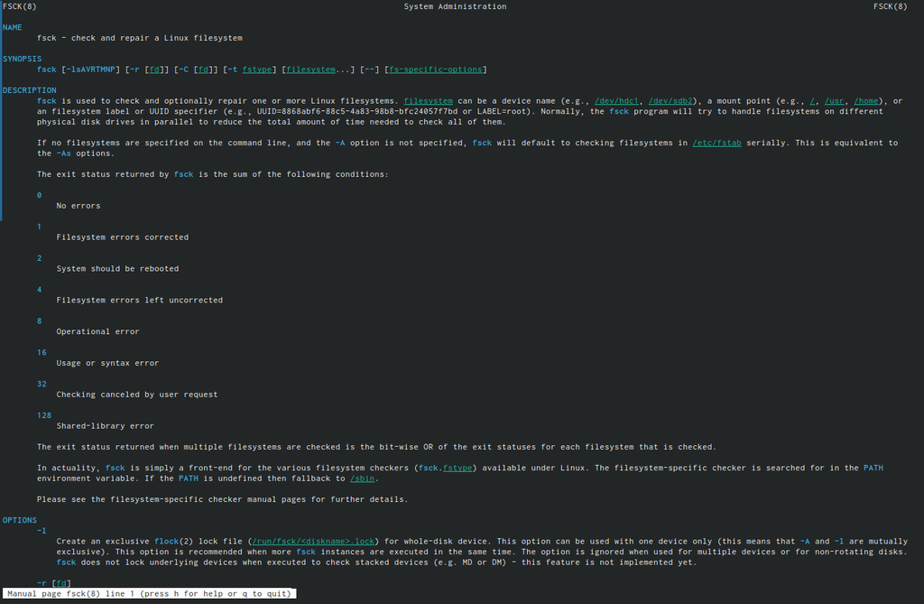

man fsck

## 5

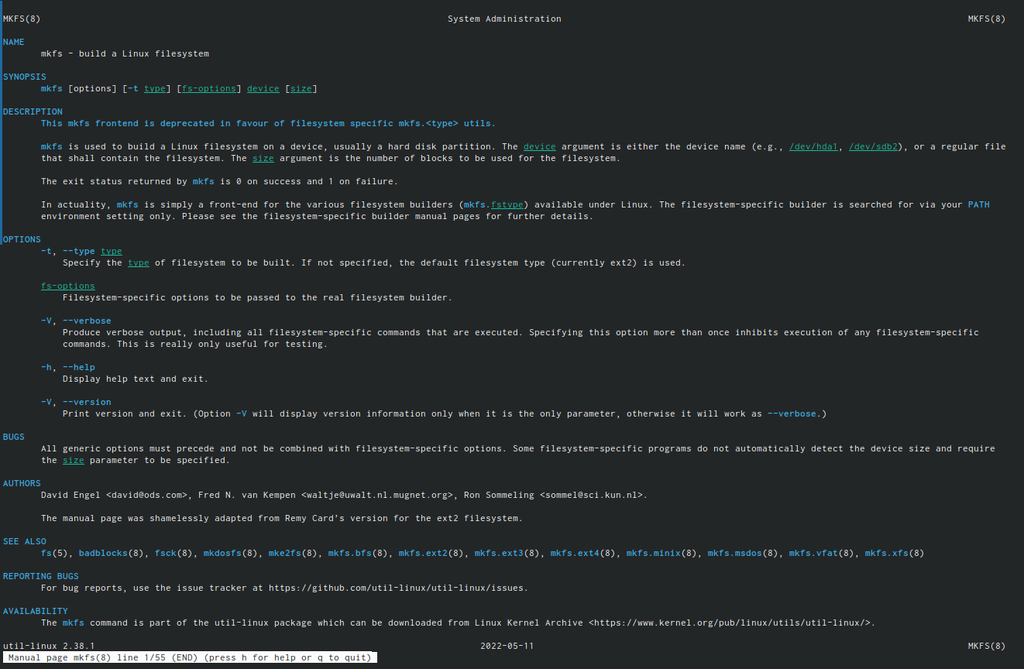

man mkfs

## 5

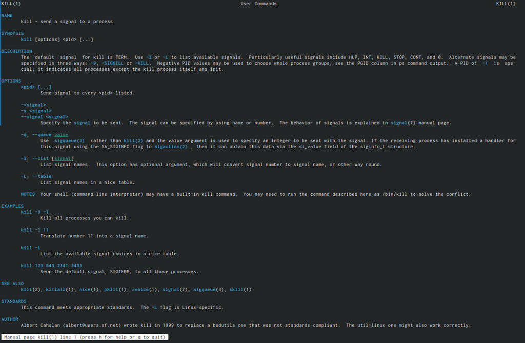

man kill

# Вывод

## Выводы

Мы ознакомились с файловой системой Linux, её структурой, именами и содержанием каталогов. Приобрели практические навыки по применению команд для работы с файлами и каталогами, по управлению процессами (и работами), по проверке исполь- зования диска и обслуживанию файловой системы.